# DBSCAN Clustering

Certainly! Here’s an example of an R Markdown document that demonstrates how to use DBSCAN to cluster the wines in the provided dataset. This data set is described in more detail in the K-Means Clustering Markdown.

## Preparing the Wine Data Set

In this example, we will use the DBSCAN algorithm to cluster the wines in the [Wine Dataset](https://archive.ics.uci.edu/ml/datasets/wine). Let’s start by loading the necessary libraries and the dataset.

```r
library(dbscan)
library(ggplot2)

# Load the Wine dataset
url <- "https://archive.ics.uci.edu/ml/machine-learning-databases/wine/wine.data"
wine_data <- read.csv(url, header = FALSE)
colnames(wine_data) <- c("Class", "Alcohol", "MalicAcid", "Ash", "Alcalinity", "Magnesium", "Phenols", "Flavanoids",
                         "NonflavanoidPhenols", "Proanthocyanins", "ColorIntensity", "Hue", "OD280_OD315", "Proline")

head(wine_data)
```

```
##   Class Alcohol MalicAcid  Ash Alcalinity Magnesium Phenols Flavanoids
## 1     1   14.23      1.71 2.43       15.6       127    2.80       3.06
## 2     1   13.20      1.78 2.14       11.2       100    2.65       2.76
## 3     1   13.16      2.36 2.67       18.6       101    2.80       3.24
## 4     1   14.37      1.95 2.50       16.8       113    3.85       3.49
## 5     1   13.24      2.59 2.87       21.0       118    2.80       2.69
## 6     1   14.20      1.76 2.45       15.2       112    3.27       3.39
##   NonflavanoidPhenols Proanthocyanins ColorIntensity  Hue OD280_OD315 Proline
## 1                0.28            2.29           5.64 1.04        3.92    1065
## 2                0.26            1.28           4.38 1.05        3.40    1050
## 3                0.30            2.81           5.68 1.03        3.17    1185
## 4                0.24            2.18           7.80 0.86        3.45    1480
## 5                0.39            1.82           4.32 1.04        2.93     735
## 6                0.34            1.97           6.75 1.05        2.85    1450
```

```r
# Exclude the Class variable
wine_data_processed <- wine_data[, -1]

# Standardize the variables
wine_data_standardized <- scale(wine_data_processed)

head(wine_data_standardized)
```

```
##        Alcohol   MalicAcid        Ash Alcalinity  Magnesium   Phenols
## [1,] 1.5143408 -0.56066822  0.2313998 -1.1663032 1.90852151 0.8067217
## [2,] 0.2455968 -0.49800856 -0.8256672 -2.4838405 0.01809398 0.5670481
## [3,] 0.1963252  0.02117152  1.1062139 -0.2679823 0.08810981 0.8067217
## [4,] 1.6867914 -0.34583508  0.4865539 -0.8069748 0.92829983 2.4844372
## [5,] 0.2948684  0.22705328  1.8352256  0.4506745 1.27837900 0.8067217
## [6,] 1.4773871 -0.51591132  0.3043010 -1.2860793 0.85828399 1.5576991
##      Flavanoids NonflavanoidPhenols Proanthocyanins ColorIntensity        Hue
## [1,]  1.0319081          -0.6577078       1.2214385      0.2510088  0.3611585
## [2,]  0.7315653          -0.8184106      -0.5431887     -0.2924962  0.4049085
## [3,]  1.2121137          -0.4970050       2.1299594      0.2682629  0.3174085
## [4,]  1.4623994          -0.9791134       1.0292513      1.1827317 -0.4263410
## [5,]  0.6614853           0.2261576       0.4002753     -0.3183774  0.3611585
## [6,]  1.3622851          -0.1755994       0.6623487      0.7298108  0.4049085
##      OD280_OD315     Proline
## [1,]   1.8427215  1.01015939
## [2,]   1.1103172  0.96252635
## [3,]   0.7863692  1.39122370
## [4,]   1.1807407  2.32800680
## [5,]   0.4483365 -0.03776747
## [6,]   0.3356589  2.23274072
```

The variables in the dataset are now standardized with a mean of 0 and a standard deviation of 1.

## Parameter Tuning

Next, we can try to identify the optimal parameters values for `eps` and `MinPts`. There are a number of ways to identify the optimal values for these parameters. Some literature suggests that `MinPts` should be at least 1 more than the number of variables subjected to the cluster analysis, which is 13 here. Other sources recommend that it should be more than 2*number of variables. Here, let’s set `MinPts` to 14 (13+1). For `eps`, we can use the `kNNdistplot` function to identify the value on the y-axis that corresponds to the knee. In the code, we set k to `MinPts` (here, k=14). The knee in the plot below corresponds to an `eps` value of approximately 4.

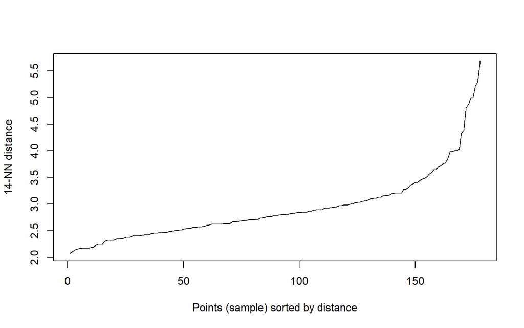

```r
kNNdistplot(wine_data_standardized, k=14)
```

Now that we’ve set `MinPts` to 14 and `eps` to 4, we can run the DBSCAN analysis with these parameter values.

```r
# Perform DBSCAN clustering
dbscan_result <- dbscan(wine_data_standardized, eps = 4, MinPts = 14)
# Extract the cluster assignments and noise points
clusters <- dbscan_result$cluster
noise <- dbscan_result$cluster == 0

# Print the number of clusters and noise points
cat("Number of clusters:", max(clusters), "\n")
```

```
## Number of clusters: 1
```

```r
cat("Number of noise points:", sum(noise), "\n")
```

```
## Number of noise points: 2
```

We can see that there’s only 1 cluster (i.e., all observations except 2 fall into one cluster). Two observations are considered noise points. Clearly putting all observations into a single cluster is not helpful, and may suggest that we need to play around with parameter values. Let’s actually set `MinPts` to 30 and see what the optimal value of `eps` 30 corresponds to (about 3.75).

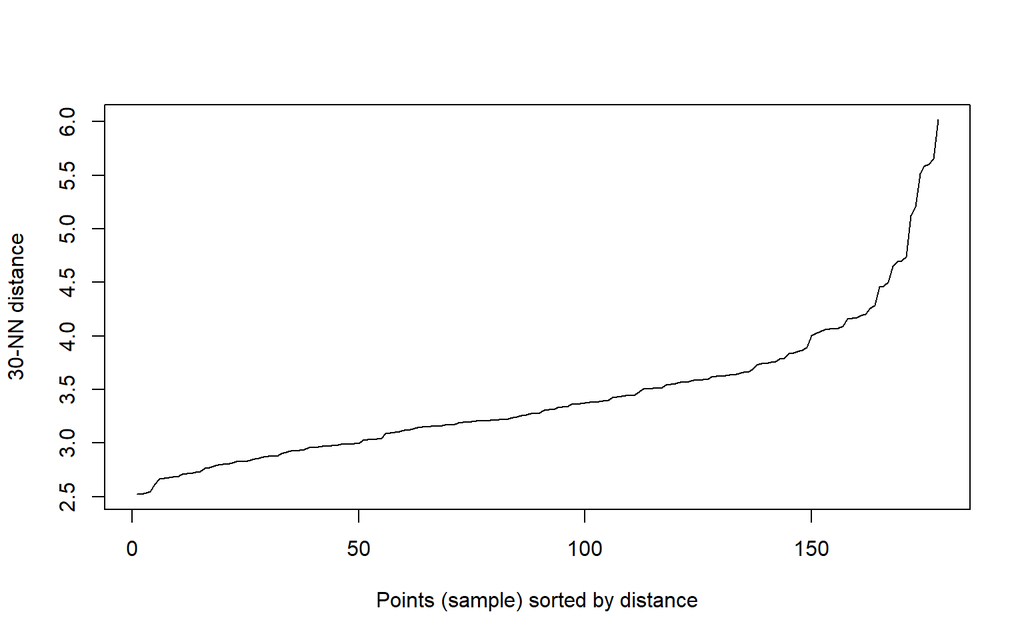

```r
kNNdistplot(wine_data_standardized, k=30)
```

Now, let’s re-run the DBSCAN analyses with new parameter values. Again, we see that we only have 1 cluster with 7 noise points, which is not a useful solution either.

```r
# Perform DBSCAN clustering
dbscan_result <- dbscan(wine_data_standardized, eps = 3.75, MinPts = 30)
# Extract the cluster assignments and noise points
clusters <- dbscan_result$cluster
noise <- dbscan_result$cluster == 0

# Print the number of clusters and noise points
cat("Number of clusters:", max(clusters), "\n")
```

```
## Number of clusters: 1
```

```r
cat("Number of noise points:", sum(noise), "\n")
```

```
## Number of noise points: 7
```

Let’s play around with some more values of `MinPts` and `eps`, and set them to 4 and 2.15, respectively. In this case, we see that there are 3 clusters with 53 noise points. This solution is certainly not consistent with recommendations from the literature, but let’s see if the solution makes sense.

```r
# Perform DBSCAN clustering
dbscan_result <- dbscan(wine_data_standardized, eps = 2.15, MinPts = 4)
# Extract the cluster assignments and noise points
clusters <- dbscan_result$cluster
noise <- dbscan_result$cluster == 0

# Print the number of clusters and noise points
cat("Number of clusters:", max(clusters), "\n")
```

```
## Number of clusters: 3
```

```r
cat("Number of noise points:", sum(noise), "\n")
```

```
## Number of noise points: 53
```

## Evaluation of Results

```r
# Add the cluster information to the dataset
round(aggregate(wine_data, by=list(cluster=clusters), mean),1)
```

```
##   cluster Class Alcohol MalicAcid Ash Alcalinity Magnesium Phenols Flavanoids
## 1       0   2.0    12.7       2.5 2.3       20.0     101.8     2.4        2.0
## 2       1   1.4    13.1       1.8 2.4       18.5      99.1     2.6        2.6
## 3       2   3.0    12.9       3.1 2.4       21.0     101.5     1.5        0.7
## 4       3   3.0    13.3       3.5 2.4       21.1      96.7     1.7        0.8
##   NonflavanoidPhenols Proanthocyanins ColorIntensity Hue OD280_OD315 Proline
## 1                 0.4             1.7            4.4 1.0         2.6   650.3
## 2                 0.3             1.7            4.4 1.1         3.0   861.2
## 3                 0.4             0.9            5.4 0.8         1.9   638.5
## 4                 0.5             1.2            8.3 0.7         1.6   619.8
```

```r
wine_data_final <- cbind(wine_data, cluster=clusters)
table(wine_data_final$Class, wine_data_final$cluster)
```

```
##
##      0  1  2  3
##   1  9 50  0  0
##   2 34 36  0  1
##   3 10  0 13 25
```